# Elements of AI

## Solutions to Exercises

### The Blueprint of Atomic Vector

**Task 1:** Create atomic vector of ten integers/doubles and name it `x`. The actual sequence does not matter, be it 1:10 or 100:109. Use `tracemem()` or `lobstr::obj_addr()` on `x`. What does the function return? What does this information tells you about the implementation of `x`?

`tracemem()` points to the memory address of `x`. There is one ID for the whole sequence of `x`, meaning that the whole sequence lives as one object in the memory.

**Task 2:** Change the value of the second element of `x` to `20`. Running `tracemem()` on `x` subsequently reports that two object addresses have been changed. The second line seems purely R Studio behavior. But what about the first line? What does this behavior refers to?

Unlike recursive vectors, atomic vectors are implemented as one solid object that has a single memory address. Adding, extracting or modifying elements of that object creates copies of the original, each having a new address. This behavior is called **copy-on-modify** and is depicted below.

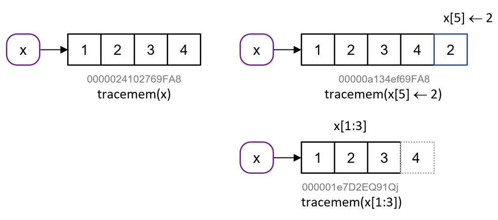

### Vectorized Arithmetic

**Task 1:** Use the sequence operator to create two vectors `x` and `y` by concatenating integers 1 through 4 (vector `x`) and 10 through 20 (vector `y`), respectively.

```r
x <- 1:4 ; y <- 10:20
```

**Task 2:** Double the value of each element of vector `x`.

```r
x * 2
```

```
## [1] 2 4 6 8
```

**Task 3:** Multiply `x` by `y` and name the resulting vector `z`. Observe what happens when you do that. What is the sum of vector elements of `z`?

```r
z <- x * y ; sum(z)
```

```
## [1] 396
```

**Task 4:** In a similar vein, think about what will result from the following computations?

- `c(1, 3, 5) + c(2, 4, 6)`
- `c(1, 3, 5) + c(2, 4, 6, 8)`
- `c(1, 3) - c(2, 4, 6 ,8)`

Tasks 3 and 4 are examples of vectorized operations and element reuse. When shorter vector is multiplied by a longer one, the shorter vector will be reused until the length of the longer vector is achieved.

```r
c(1, 3, 5) + c(2, 4, 6)
```

```
## [1]  3  7 11
```

```r
c(1, 3, 5) + c(2, 4, 6, 8)
```

```
## [1]  3  7 11  9
```

```r
c(1, 3) - c(2, 4, 6 ,8)
```

```
## [1] -1 -1 -5 -5
```

**Task 5:** Write a R program to find the elements of a given vector that are not in another given vector.

```r
x <- 1:10 ; y <- 5:20 ; y[x]
```

```
##  [1]  5  6  7  8  9 10 11 12 13 14
```

**Task 6:** Write a R program to count the specific value in a given vector.

```r
x <- c(1, 2, 3, 3, 3, 4, 5, 5) ; sum(x == 2)
```

```
## [1] 1
```

**Task 7:** Create a numeric vector with the same length as `x`, but containing only integer `3`.

```r
rep(3,length(x)) # c(3,3,3,3) works well enough.
```

```
## [1] 3 3 3 3 3 3 3 3
```

**Task 8:** Create vector `x` containing a sequence of numbers from 1 to 5, where each number occurs the same number of times as the number itself, eg. 1, 2, 2, 3, 3, 3…

```r
rep(1:5, 1:5)
```

```
##  [1] 1 2 2 3 3 3 4 4 4 4 5 5 5 5 5
```

**Task 9:** Use vectorized nature of R to calculate the following. Do not use loops (which you haven’t learned yet).
$$a) \sum_{i=10}^{100} (i^3 + 4i^2)$$
$$b) \sum_{i=1}^{25} (\frac{2^i}{i} +
\frac{3^i}{i^2})$$

```r
tmp <- 10:100  ; sum(tmp^3+4*tmp^2) # Solution of A.
```

```
## [1] 26852735
```

```r
tmp <- 1:25 ; sum((2^tmp)/tmp + 3^tmp/(tmp^2)) # Solution of B.
```

```
## [1] 2129170437
```

### Sequence Magic

**Task 1:** Write a R program that extracts every n<sup>th</sup> element of `x <- 1:100`.

```r
x <- 1:100
stepping <- 5
x[seq(1, length(x), stepping)]
```

```
##  [1]  1  6 11 16 21 26 31 36 41 46 51 56 61 66 71 76 81 86 91 96
```

**Task 2:** Write a R program that count the number of values in a range in a given vector (say, `x <- 1:200`). For example, sum all integers between 10 and 50 including.

```r
x <- 1:200
sum(x >= 10 & x <= 50)
```

```
## [1] 41
```

**Task 3:** Write a R program that reverses an order of a vector.

```r
x <- 1:10
rev(x)
```

```
##  [1] 10  9  8  7  6  5  4  3  2  1
```

**Task 4:** There’s an old parable that goes something like this. A man does some work for a king and needs to be paid. Because the man loves rice (who doesn’t?!), the man offers the king two different ways that he can be paid. *You can either pay me 100 kilograms of rice, or, you can pay me as follows: get a chessboard and put one grain of rice in the top left square. Then put 2 grains of rice on the next square, followed by 4 grains on the next, 8 grains on the next…and so on, where the amount of rice doubles on each square, until you get to the last square. When you are finished, give me all the grains of rice that would (in theory), fit on the chessboard.* The king, sensing that the man was an idiot for making such a stupid offer, immediately accepts the second option. He summons a chessboard, and begins counting out grains of rice one by one…

- Assuming that there are 64 squares on a chessboard, calculate how many grains of rice the main will receive.
- If one grain of rice weights 1/6400 kilograms, calculate how many kilograms of rice did he get.
- If a kilogram of rice has 1300 calories, calculate how many calories would that be.
- If a person needs 2250 calories a day, calculate how many people-year would that amount feed.
- Assuming that average life span of an individual is 70 years, calculate how many lifespans could this amount of rice feed.

Considering these numbers, conclude how wise the king was. Print you report on screen summarizing all calculations.

```r
exp <- 0:63
rice <- sum(2^exp) # Calculates the number of rice on a checkboard.
weight <- rice * (1/6400)
calories <- weight * 1300
peopleYear <- calories / (2250*365)
lifeSpan <- peopleYear / 70

paste("A king will have to put", format(rice, scientific=TRUE), "grains of rice on a chessboard, weighting", format(weight, scientific=TRUE), "kilograms. From this amount", format(lifeSpan, scientific=TRUE), "people can be fed over their lifespan, assuming that there were", format(peopleYear, scientific=TRUE), "people-year calories in that pile of rice.")
```

```
## [1] "A king will have to put 1.844674e+19 grains of rice on a chessboard, weighting 2.882304e+15 kilograms. From this amount 6.51793e+10 people can be fed over their lifespan, assuming that there were 4.562551e+12 people-year calories in that pile of rice."
```

```r
paste("Conclusion: king messed up.")
```

```
## [1] "Conclusion: king messed up."
```